# AiBtcQuantLandia

Analiza działalności parku w latach 2021 – 2023

[figure not shown]

# 1 Wstęp

## 1.1 Cel analizy

Celem niniejszego raportu jest analiza danych dotyczących funkcjonowania parku rozrywki **AiBtcQuantLandia**, ze szczególnym uwzględnieniem zachowań odwiedzających oraz wykorzystaniem atrakcji.

Wyniki analizy mają na celu wsparcie procesu podejmowania decyzji dot. działalności parku. Uzyskane wnioski mogą zostać wykorzystane do poprawy jakości obsługi, lepszego planowania oraz zwiększenia satysfakcji klientów.

## 1.2 Źródła danych

Analiza została przeprowadzona w oparciu o dane ilościowe, zgromadzone w bazie danych **aibtcquantlandia**. Umożliwiają one identyfikację kluczowych trendów, zależności oraz potencjalnych obszarów wymagających optymalizacji.

Jest to obszerna baza - zawierająca 35 tabel (attraction_failures, attraction_inspections, attraction_sessions, attraction_types, attractions, channels, cost_categories, employee_salary_history, employees, financial_transactions, guests, incidents, insurance_policies, insurers, investment_milestones, operating_costs, partner_contracts, partners, payment_methods, planned_investments, policy_coverages, policy_types, positions, product_categories, session_modes, shop_inventory_movements, shop_price_list, shop_products, shop_sale_items, shop_sales, ticket_price_list, ticket_types, tickets, unpleasant_event_types, visits).

Ze względu na rozmiar bazy w analizie wykorzystano jedynie wybrane tabele i kolumny, które były niezbędne do odpowiedzi na postawione pytania badawcze.

Zakres czasowy danych obejmuje wizyty w parku od **2021-01-01** do **2023-12-31**, co pozwala na analizę trendów i zachowań klientów w tym okresie działalności parku.

## 1.3 Pytania badawcze

W raporcie skupiono się na następujących pytaniach badawczych:

- 1) **Najpopularniejsze atrakcje i ich opłacalność**: Które atrakcje przyciągają najwięcej gości? Jak wyglądają koszty i zyski poszczególnych atrakcji? Jak czasowa niedostępność atrakcji wpływała na przychody parku?
- 2) **Liczba klientów w czasie**: Jak wygląda liczba obsłużonych klientów w poszczególnych miesiącach działalności parku? Czy obserwujemy tendencję wzrostową czy spadkową?
- 3) **Bezpieczeństwo atrakcji**: Które atrakcje mogą być zbyt niebezpieczne? Czy konieczne są działania poprawiające bezpieczeństwo?
- 4) **Średni wiek gości**: Jaki jest przeciętny wiek odwiedzających park?
- 5) **Sprzedaż biletów**: Ile biletów sprzedano w różnych latach? Jak zmienia się proporcja sprzedanych typów biletów?
- 6) **Sprzedaż produktów w sklepach**: Które produkty sprzedają się najlepiej? Czy struktura sprzedażu zależy od pory roku?
- 7) **Preferencje płatności**: Jakie metody płatności najczęściej wybierają klienci?

# 2 Analiza

## 2.1 Które atrakcje są najpopularniejsze, jaka jest ich opłacalność?

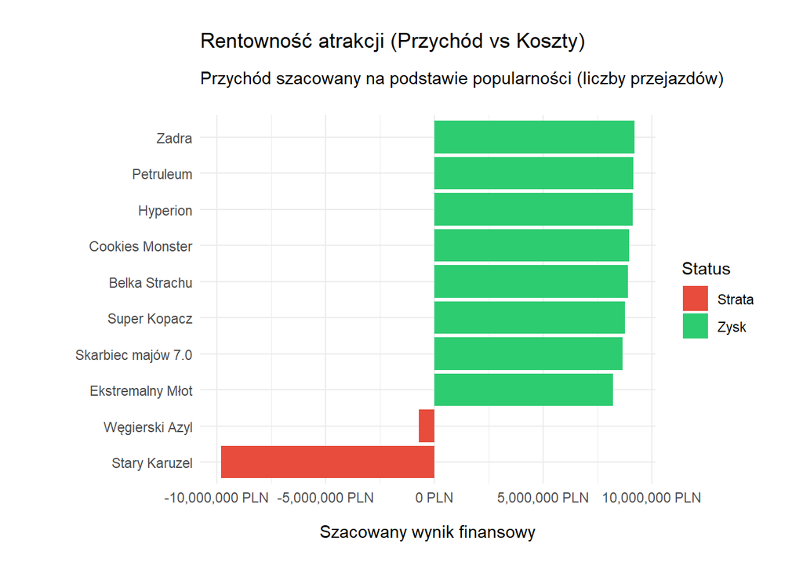

Figure 2.1: Wykres przychodu w zależności od atrakcji, atrakcje uporządkowane od najbardziej do najmniej popularnej

Popularność atrakcji określono na podstawie łącznej liczby przejazdów, zliczając wszystkie sesje przypisane do danej atrakcji w tabeli `attraction_sessions`.

Koszty atrakcji wyznaczono jako sumę trzech kategorii: kosztów operacyjnych, kosztów incydentów oraz kosztów napraw po awariach.

Przychód przypisany do atrakcji oszacowano proporcjonalnie do jej udziału w łącznej liczbie przejazdów względem całkowitego przychodu ze sprzedaży biletów. Natomiast zysk obliczono jako różnicę między oszacowanym przychodem a całkowitym kosztem, co pozwoliło sklasyfikować atrakcje jako rentowne lub nierentowne.

Wyniki tej analizy można znaleźć na wykresie 2.1. Należy zaznaczyć, że atrakcje zostały uporządkowane od najbardziej do najmniej popularnej. Zdecydowana ich większość przyniosła zyski, mieszczące się w przedziale od około **7,5 do 9 mln złotych**. Dwie atrakcje — **Stary Karuzel** oraz **Węgierski Azyl** — przyniosły straty. Szczególnie uwagę zwraca atrakcja **Stary Karuzel**, której skumulowana strata wyniosła niemal **10 mln zł**. Co istotne, właśnie te dwie atrakcje charakteryzują się najmniejszą liczbę uruchomień oraz najwyższymi kosztami wynikającymi z awarii oraz incydentów (patrz pytanie 3).

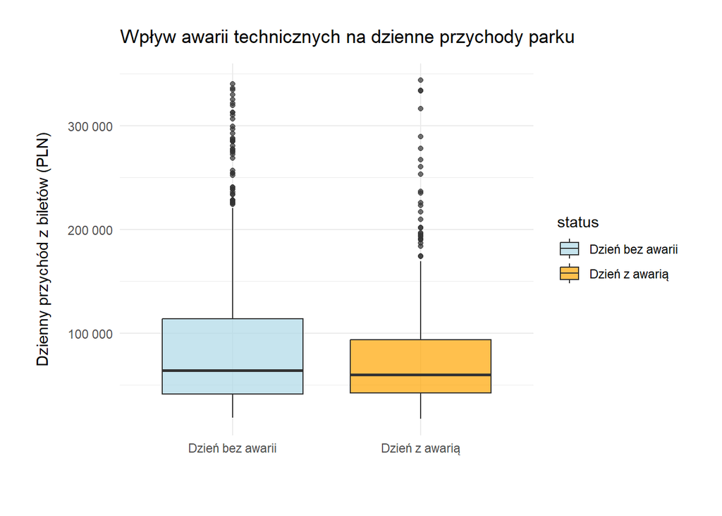

Figure 2.2: Wykres pudełkowy obrazujący wpływ awarii na przychody

Widoczne na wykresie wartości odstające odpowiadają dniom o wyjątkowo wysokiej frekwencji (patrz pytanie 2). Także w ich przypadku utrzymuje się obserwowana zależność — wyższe przychody występowały częściej w dniach bez awarii.

## 2.2 Jak zmieniała się liczba klientów w czasie?

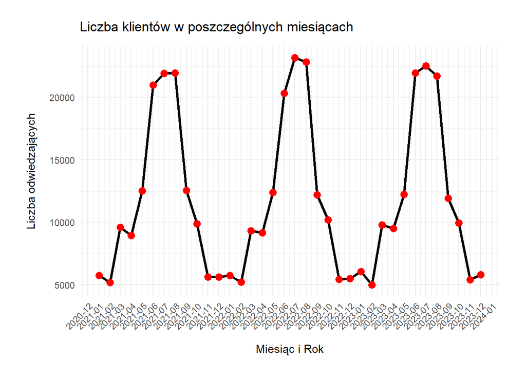

Figure 2.3: Wykres liczby gości w poszczególnych miesiącach

Liczbę klientów w czasie przeanalizowano na podstawie danych z tabeli `visits`. Wizyty zostały zsumowane w ujęciu miesięcznym.

Na wykresie 2.3 przedstawiono liczbę odwiedzających park w kolejnych miesiącach działalności. Widoczna jest wyraźna sezonowość — liczba klientów wzrasta w miesiącach wiosenno-letnich, natomiast spada w okresie jesienno-zimowym.

W analizowanym okresie nie zaobserwowano trendu wzrostowego ani spadkowego. Liczba gości w tych samych miesiącach kolejnych lat utrzymuje się na porównywalnym poziomie, co wskazuje na stabilność liczby odwiedzających.

## 2.3 Które atrakcje są (nie)bezpieczne?

W celu oceny bezpieczeństwa atrakcji przeanalizowano dwa rodzaje zdarzeń: awarie mechaniczne oraz incydenty z udziałem gości. Dane zestawiono na poziomie poszczególnych atrakcji, agregując liczbę zdarzeń, ich średnią dotkliwość oraz łączne koszty finansowe.

Table 2.1: Statystyki dotyczące awarii atrakcji i koszt naprawy

| Nazwa atrakcji | Liczba awarii | Średnia dotkliwość | Łączny koszt napraw (zł) |
| --- | --- | --- | --- |
| Belka Strachu | 12 | 4.17 | 109024 |
| Cookies Monster | 14 | 4.07 | 105875 |
| Ekstremalny Młot | 29 | 3.97 | 253903 |
| Hyperion | 11 | 4.00 | 83627 |
| Petruleum | 7 | 3.57 | 73298 |
| Skarbiec majów 7.0 | 26 | 4.12 | 190990 |
| Stary Karuzel | 126 | 3.93 | 4263196 |
| Super Kopacz | 18 | 3.67 | 153141 |
| Węgierski Azyl | 57 | 3.95 | 1993129 |
| Zadra | 7 | 3.86 | 54272 |

Tabela 2.1 przedstawia statystyki dotyczące awarii mechanicznych. Najwięcej awarii odnotowano w przypadku atrakcji **Stary Karuzel** (126 awarii), co przełożyło się na najwyższe koszty napraw — ponad 4,2 mln zł. Istotną liczbę awarii odnotowano również dla **Węgierskiego Azylu** (57 awarii), **Ekstremalnego Młota** (29 awarii) i **Skarbca Majów 7.0** (26 awarii), generując odpowiednio wysokie koszty utrzymania technicznego. Najmniej awarii odnotowano dla atrakcji **Petruleum** oraz **Zadra**, co wskazuje na większą niezawodność tych urządzeń.

Table 2.2: Statystyki dotyczące wypadków w użytkowaniu atrakcji oraz szacowany poniesiony koszt

| Nazwa atrakcji | Liczba wypadków | Średnia dotkliwość | Szacowany koszt (zł) |
| --- | --- | --- | --- |
| Belka Strachu | 69 | 1.90 | 26200 |
| Cookies Monster | 28 | 1.50 | 8400 |
| Ekstremalny Młot | 82 | 3.02 | 49600 |
| Hyperion | 16 | 1.00 | 3200 |
| Petruleum | 0 | NA | 0 |
| Skarbiec majów 7.0 | 27 | 1.63 | 8800 |
| Stary Karuzel | 10 | 1.00 | 2000 |
| Super Kopacz | 37 | 1.54 | 11400 |
| Węgierski Azyl | 19 | 1.00 | 3800 |
| Zadra | 28 | 1.00 | 5600 |

Tabela 2.2 przedstawia dane dotyczące incydentów z udziałem gości. Najwięcej wypadków miała atrakcja **Ekstremalny Młot** (82 zdarzenia) z najwyższą średnią dotkliwością 3,02, co sugeruje większe ryzyko dla bezpieczeństwa odwiedzających. Pomimo dużej liczby awarii, atrakcja **Stary Karuzel** odnotowała stosunkowo niewiele wypadków wśród gości (10 zdarzeń). Z kolei **Belka Strachu** miała wysoką liczbę incydentów (69), jednak średnia dotkliwość była stosunkowo niska (1,90), co sugeruje, że zdarzenia były głównie drobne.

Łączna interpretacja obu tabel pozwala wyróżnić atrakcje wymagające szczególnej uwagi: **Stary Karuzel** i **Węgierski Azyl** ze względu na wysokie koszty awarii, oraz **Ekstremalny Młot** ze względu na liczne i stosunkowo poważne incydenty z udziałem gości.

Warto zauważyć, że to właśnie atrakcje **Stary Karuzel** i **Węgierski Azyl**, które generują najwyższe koszty awarii i incydentów, jednocześnie przyniosły straty finansowe (patrz pytanie 1).

## 2.4 Jaki jest średni wiek gościa parku?

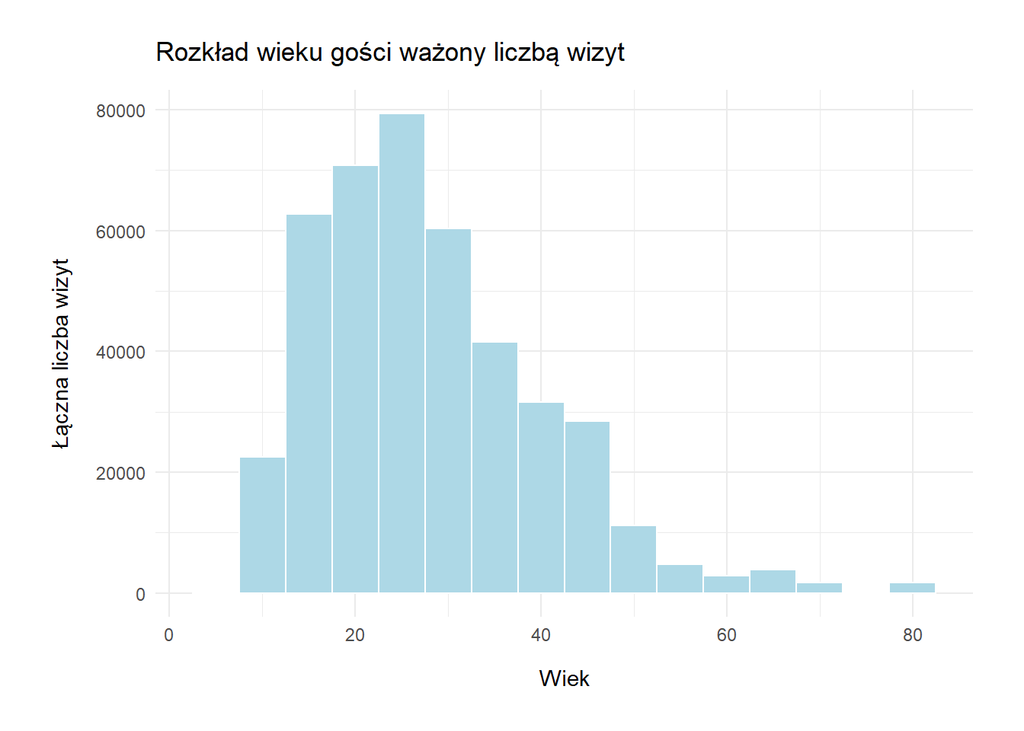

Figure 2.4: Histogram wieku gości parku ważony liczbą wizyt

Analizę wieku gości przeprowadzono na podstawie danych z tabeli `guests`, łącząc je z informacjami o wizytach (tabela `visits`). Dla każdego gościa uwzględniono liczbę wizyt jako wagę, aby lepiej oddać faktyczny udział różnych grup wiekowych w aktywności parku.

Średni wiek odwiedzających wynosi 28.05, a mediana to 26. Na wykresie 2.4 widać, że największą liczbę wizyt generują goście w wieku od około 15 do 40 lat, co wskazuje, że park najczęściej odwiedzają młodzi dorośli i osoby w średnim wieku. Mniejsze znaczenie mają wizyty dzieci oraz osób starszych, choć także te grupy są obecne w danych.

## 2.5 Jakie bilety się najlepiej sprzedają?

Analizę sprzedaży biletów przeprowadzono na podstawie danych z tabel `tickets` oraz `ticket_types`. Obliczono łączną liczbę sprzedanych biletów dla poszczególnych typów oraz ich udział procentowy w całkowitej sprzedaży.

Table 2.3: Liczba sprzedanych biletów

| Typ biletu | Liczba sprzedanych sztuk (tyś.) | Udział procentowy |
| --- | --- | --- |
| Normalny | 134.07 | 31.62 |
| Ulgowy | 122.75 | 28.95 |
| Rodzinny | 117.35 | 27.68 |
| VIP FastPass | 49.82 | 11.75 |

Tabela 2.3 przedstawia liczbę sprzedanych biletów według typu. Największą popularnością cieszą się bilety normalne, nieco mniej ulgowe oraz rodzinne. Najmniejszy udział mają bilety VIP FastPass.

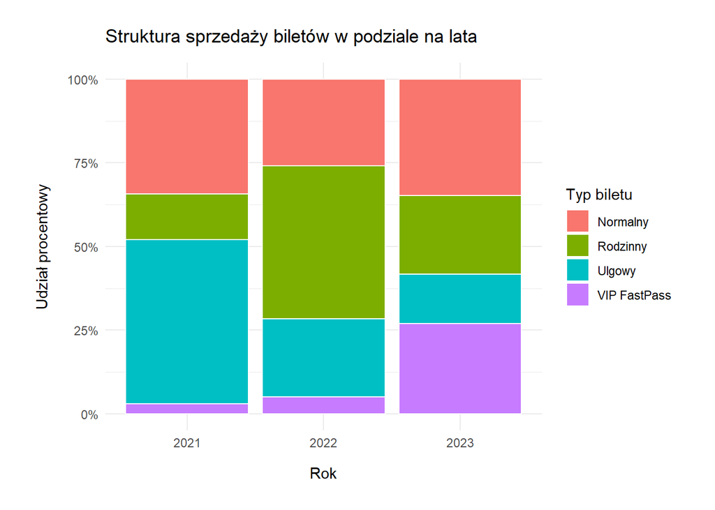

Figure 2.5: Wykres udziału procentowego poszczególnych typów sprzedanych biletów

Dodatkowo przeanalizowano sprzedaż biletów w podziale na lata. Wykres 2.5 pokazuje strukturę sprzedaży w kolejnych latach i wskazuje, że proporcje poszczególnych typów biletów zdecydowanie się zmieniły.

## 2.6 Które produkty w sklepach się najlepiej sprzedają?

Analizę sprzedaży sklepowej przeprowadzono na podstawie danych z tabel `shop_sale_items`, `shop_products` oraz `shop_sales`. Dla każdego produktu obliczono łączną liczbę sprzedanych sztuk, wygenerowany przychód, koszt zakupu towaru oraz dochód stanowiący różnicę między przychodem a kosztem.

Table 2.4: Sprzedaż produktów w parkowych sklepach

| Produkt | Cena (zł/szt.) | Sprzedane (tyś. szt.) | Koszt (tyś. zł) | Przychód (tyś. zł) | Dochód (tyś. zł) |
| --- | --- | --- | --- | --- | --- |
| Koszulka Logo | 69 | 11.8 | 212.0 | 812.7 | 600.7 |
| Lody Włoskie | 8 | 90.8 | 136.2 | 726.5 | 590.3 |
| Burger Classic | 32 | 23.4 | 187.2 | 748.9 | 561.7 |
| Pluszowy Miś | 55 | 11.9 | 179.0 | 656.5 | 477.4 |
| Czapka z daszkiem | 45 | 11.9 | 142.9 | 535.9 | 393.0 |
| Magnes Parkowy | 15 | 30.0 | 59.9 | 449.5 | 389.6 |
| Coca Cola 0.5L | 9 | 58.1 | 145.3 | 523.1 | 377.8 |
| Woda Mineralna 0.5L | 6 | 74.0 | 74.0 | 443.9 | 369.9 |
| Peleryna Przeciwdeszczowa | 25 | 17.8 | 89.2 | 445.9 | 356.7 |
| Kawa Espresso | 12 | 30.1 | 30.1 | 360.9 | 330.8 |
| Frytki Małe | 12 | 23.5 | 47.0 | 281.7 | 234.8 |
| Zapiekanka XXL | 22 | 11.8 | 47.2 | 259.4 | 212.2 |
| Smycz do kluczy | 20 | 12.0 | 35.9 | 239.6 | 203.7 |
| Gofr z owocami | 18 | 11.9 | 35.7 | 214.5 | 178.7 |

Zestawienie wyników przedstawiono w tabeli 2.4. Analiza sprzedaży pokazuje, że największe dochody generowały produkty gastronomiczne oraz wybrane artykuły pamiątkowe. Na tle pozostałych szczególnie wyróżniają się **Koszulka Logo** (600 tys. zł), **Lody Włoskie** (590 tys. zł) oraz **Burger Classic** (561 tys. zł). Ich wysoka dochód jest efektem dużej skali sprzedaży lub relatywnie wysokiej ceny.

Z kolei pod względem liczby sprzedanych sztuk dominują produkty o niskiej cenie jednostkowej — przede wszystkim **Lody Włoskie (90 815 szt.)** oraz **Woda Mineralna 0.5L** (73 977 szt.).

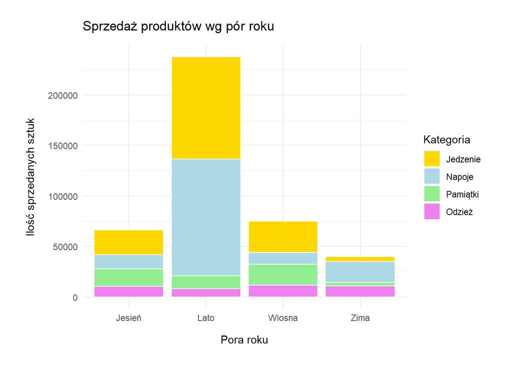

Figure 2.6: Liczba sprzedanych produktów w zależności od pory roku

Dodatkowo przeanalizowano sezonowość sprzedaży — jak zmienia się w zależności od pory roku i rodzaju produktów. Wyniki przedstawiono na wykresie 2.6. Widoczna jest wyraźna zależność sprzedaży od sezonu — największa przypada na okresy, gdy park odwiedza najwięcej gości (patrz pytanie 2).

Zmienia się również struktura sprzedaży. Latem goście częściej kupują napoje i jedzenie, które zaspokajają bieżące potrzeby podczas pobytu w parku, natomiast rzadziej sięgają po pamiątki. W pozostałych porach roku udział produktów pamiątkowych jest relatywnie większy, co pokazuje, że preferencje zakupowe odwiedzających różnią się w zależności od sezonu.

## 2.7 Jak płacą klienci?

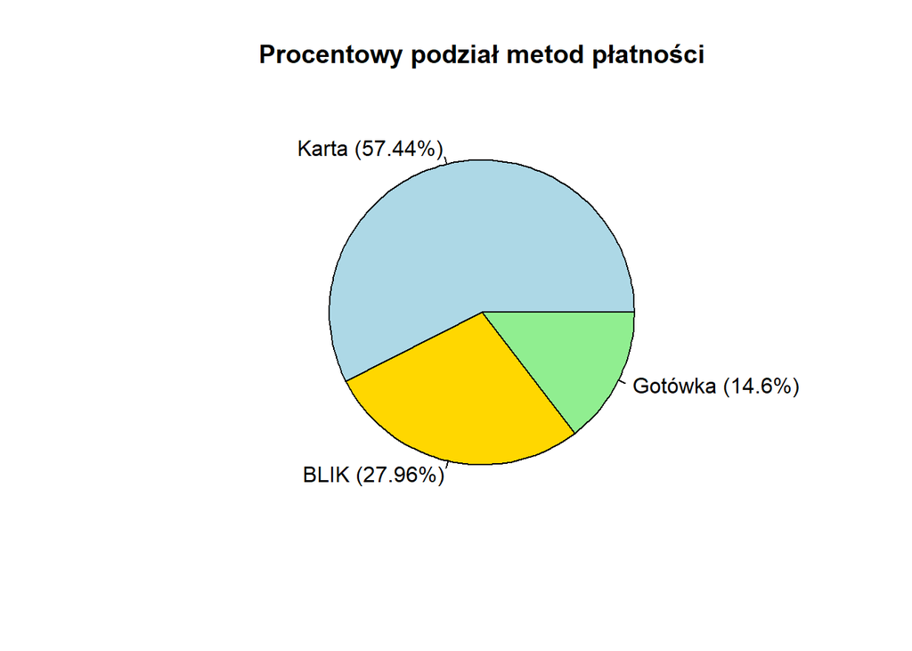

Figure 2.7: Wykres kołowy sposobów płatności

Analizę metod płatności gości przeprowadzono w oparciu o dane z tabel `financial_transactions` oraz `payment_methods`. Uwzględniono zarówno liczbę transakcji, jak i łączną wartość przychodów z płatności przychodzących. Procentowy podział wartości transakcji według sposobu płatności zaprezentowano na wykresie 2.7.

Wyniki jednoznacznie wskazują, że klienci zdecydowanie preferują płatności elektroniczne, natomiast transakcje gotówkowe stanowią jedynie 14,6% wszystkich operacji.

# 3 Wnioski końcowe

## 3.1 Rekomendacje

- **Ocena opłacalności nierentownych atrakcji**  
  Dla atrakcji *Stary Karuzel* i *Węgierski Azyl* zaleca się przeprowadzenie szczegółowej analizy kosztów i korzyści dalszej eksploatacji. Powinna ona obejmować przegląd techniczny, estymację kosztów modernizacji oraz porównanie ich z potencjalnymi stratami wynikającymi z utrzymania lub wycofania atrakcji. Więcej szczegółów — pytanie 1.
- **Ograniczanie wpływu awarii na przychody**  
  Ponieważ dni bez awarii generują wyższe przychody z biletów, warto inwestować w prewencyjną konserwację atrakcji, lepsze planowanie serwisów oraz utrzymywanie zapasu kluczowych części zamiennych. Działania te zwiększają stabilność przychodów i ograniczają ryzyko finansowe. Więcej szczegółów — pytanie 1.
- **Wzmocnienie bezpieczeństwa i zarządzania ryzykiem**  
  Atrakcje z dużą liczbą incydentów lub wysoką dotkliwością (szczególnie *Ekstremalny Młot*) wymagają natychmiastowej kontroli bezpieczeństwa. Rekomenduje się zaostrzenie procedur, częstsze przeglądy techniczne oraz rozważenie wyższych kosztów ubezpieczenia. Więcej szczegółów — pytanie 3.
- **Promocja parku wśród różnych grup wiekowych**  
  Z uwagi na strukturę wiekową gości rekomenduje się prowadzenie akcji promocyjnych zwiększających atrakcyjność parku dla dzieci i osób starszych. Więcej szczegółów — pytanie 4.
- **Optymalizacja struktury sprzedaży biletów**  
  Warto przyjrzeć się temu, jak zmiany cen poszczególnych rodzajów biletów wpływają na sprzedaż, a także testować różne promocje, takie jak pakiety rodzinne czy zachęty do zakupu biletów VIP FastPass. Dzięki temu można zwiększyć średnią wartość kupowanego biletu. Więcej szczegółów — pytanie 5.
- **Rozwój sprzedaży w sklepach**  
  Koncentracja na najbardziej dochodowych produktach (np. *Koszulka Logo*, *Lody Włoskie*, *Burger Classic*) oraz wprowadzenie dynamicznych cen sezonowych może znacząco zwiększyć przychody i poprawić zarządzanie zapasami. Więcej szczegółów — pytanie 6.
- **Dostosowanie zasobów sklepu do sezonu**  
  Ze względu na wyraźną sezonowość ruchu w parku, zasadne jest elastyczne planowanie personelu, asortymentu sklepów oraz poziomu zapasów. W okresach poza sezonem warto rozważyć działania promocyjne zwiększające atrakcyjność oferty sklepu lub zmianę asortmentu. Więcej szczegółów — pytanie 6.
- **Promowanie płatności bezgotówkowych**  
  Ze względu na przewagę płatności elektronicznych warto kontynuować ich promowanie, m.in. poprzez odpowiednią infrastrukturę terminalową. Może to obniżyć koszty obsługi oraz skrócić czas realizacji transakcji. Więcej szczegółów — pytanie 7.